# Where to Open the Next Gong-Cha Tea Shops

About Gong Cha: At Gong Cha, they believe in serving quality bubble tea. Their teas can be blended with a variety of fruits, toppings and creative mixes. Gong Cha prides itself on offering fresh tea and toppings to our customer’s everyday. How do we do this? Our tea and tapioca pearls are kept fresh every four hours. Bubble tea is our specialty and we are excited to have our customers enjoy a great cup of tea with Gong Cha. (From Gong Cha Official website). Gong cha is one of my favorite Drink shop in New York, using the data provided and the data I found on Internet, I would like to help Gong Cha make the decision of where to open the next Cong Cha Shop.

In the following analysis. I will make the decision of where to open the next Gong Cha Shops among the new buildings that applied their permit in 2018. I will mainly focus on Manhattan and use the data of DOB permit issuance, data of New York Census, data of Zip_Zri house rental price, data of existing Gong Cha shop, and data of its main competitor Kungfu Tea to facilitate my analysis.

## Play with DOB Data

```python
import pandas as pd
import numpy as np
```

```python
myData = pd.read_csv("../Desktop/DOB_Permit_Issuance.csv",low_memory = False )
```

Take a look of our data:

```python
pd.set_option("max_columns", 500)
myData.sample(5)
```

|  | BOROUGH | Bin # | House # | Street Name | Job # | Job doc. # | Job Type | Self_Cert | Block | Lot | Community Board | Zip Code | Bldg Type | Residential | Special District 1 | Special District 2 | Work Type | Permit Status | Filing Status | Permit Type | Permit Sequence # | Permit Subtype | Oil Gas | Site Fill | Filing Date | Issuance Date | Expiration Date | Job Start Date | Permittee's First Name | … |
| --- | --- | --- | --- | --- | --- | --- | --- | --- | --- | --- | --- | --- | --- | --- | --- | --- | --- | --- | --- | --- | --- | --- | --- | --- | --- | --- | --- | --- | --- | --- |
| 2600439 | STATEN ISLAND | 5154783 | 55 | EASTENTRY ROAD | 500499579 | 1 | NB | Y | 00884 | 00001 | 502 | 10304.0 | 2.0 | NaN | NaN | NaN | NaN | ISSUED | RENEWAL | NB | 2 | NaN | NaN | ON-SITE | 07/09/2002 12:00:00 AM | 07/12/2002 12:00:00 AM | 01/24/2003 12:00:00 AM | 04/01/2002 12:00:00 AM | VINCENT | … |
| 1634851 | MANHATTAN | 1072007 | 667 | MADISON AVENUE | 110396919 | 1 | A2 | N | 01375 | 00049 | 108 | 10065.0 | 2.0 | NaN | MID | NaN | OT | ISSUED | RENEWAL | EW | 2 | OT | NaN | NOT APPLICABLE | 04/03/2009 12:00:00 AM | 04/09/2009 12:00:00 AM | 04/01/2010 12:00:00 AM | 01/08/2009 12:00:00 AM | JIM | … |
| 2051902 | STATEN ISLAND | 5084827 | 1826 | CARLTON AVENUE | 500840995 | 1 | DM | NaN | 06913 | 00074 | 503 | 10309.0 | 2.0 | NaN | NaN | NaN | EQ | ISSUED | INITIAL | EQ | 1 | FN | NaN | ON-SITE | 07/14/2006 12:00:00 AM | 07/14/2006 12:00:00 AM | 12/31/2006 12:00:00 AM | 07/14/2006 12:00:00 AM | EDWARD | … |
| 2937187 | MANHATTAN | 1086217 | 325 | EAST 115 STREET | 101234512 | 2 | NB | NaN | 01687 | 00014 | 111 | 10029.0 | 2.0 | NaN | NaN | NaN | PL | ISSUED | RENEWAL | PL | 2 | NaN | NaN | NONE | 03/31/1999 12:00:00 AM | 03/31/1999 12:00:00 AM | 03/30/2000 12:00:00 AM | 02/25/1998 12:00:00 AM | WILLIAM | … |
| 650463 | MANHATTAN | 1008494 | 42 | BOND STREET | 140400947 | 1 | A2 | Y | 00530 | 00046 | 102 | 10012.0 | 2.0 | NaN | NaN | NaN | OT | ISSUED | INITIAL | EW | 1 | OT | NaN | NOT APPLICABLE | 09/11/2015 12:00:00 AM | 09/11/2015 12:00:00 AM | 05/12/2016 12:00:00 AM | 09/11/2015 12:00:00 AM | SEBASTIAN | … |

```python
BOROUGH_count = myData["BOROUGH"].value_counts()
```

A historgram of Number of Applications for different Borough in New York:

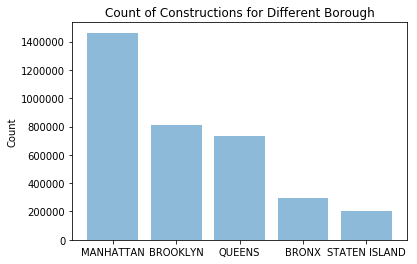

```python
import matplotlib.pyplot as plt
#BOROUGH_count
places = BOROUGH_count.index.tolist()
counts = BOROUGH_count.tolist()
plt.bar(places, counts, align='center', alpha=0.5)
plt.ylabel('Count')
plt.title('Count of Constructions for Different Borough')
plt.show()
```

Add constrain to the data set to narrow the topic mainly focused on Manhattan area and with new issued bulidings.

```python
newData = myData[(myData['Job Type'] == 'NB') &
                   (myData['Permit Type'] == 'NB') &
                   (myData['Permit Status'] == 'ISSUED') &
                   (myData['BOROUGH'] == "MANHATTAN")]
```

```python
len(newData)
```

```
11527
```

```python
# Define a function to process with dates variable:
import arrow
def convert_time(date):
    if isinstance(date, float):
        return np.nan
    else:
        return np.datetime64(arrow.get(date.split(" ")[0], 'MM/DD/YYYY').datetime)
newData['Issuance Date'] = [convert_time(date)
                             for date in newData['Issuance Date']]
```

```python
#newData.sample(5)
```

Take only useful columns of the dataset:

```python
newData = newData[['Zip Code','Residential','Issuance Date','LATITUDE','LONGITUDE','CENSUS_TRACT']]
```

```python
newData.sample(5)
```

[output not shown]

The earliest dates of application in the data set:

```python
min(newData['Issuance Date'])
```

```
Timestamp('1991-01-08 00:00:00')
```

```python
newData['Issuance_Year'] = [date.year
                             for date in newData['Issuance Date']]
#newData.isnull().sum(axis = 0)
```

Clean the data and dealed with null value:

```python
newData.replace(["NaN", 'NaT'], np.nan, inplace = True)
newData.dropna(subset=['LATITUDE','LONGITUDE'],inplace= True)
newData['Residential'] = newData['Residential'].astype(str)
```

### Visualize the distribution of in map:

```python
import folium
import pandas as pd
NY_COORDINATES = [40.78, -73.97]
# for speed purposes
MAX_RECORDS = 10000
# create empty map zoomed in on San Francisco
map = folium.Map(location=NY_COORDINATES, zoom_start=12,tiles = "Stamen Terrain",)
newData_year = newData[(newData['Issuance_Year'] == 2018)]
#newData_year.sample(5)
```

```python
newData_year_residential = newData_year[(newData_year['Residential'] == "YES")]
newData_year_non_residential = newData_year[(newData_year['Residential'] != "YES")]
```

```python
for each in newData_year_non_residential.iterrows():
    folium.Marker(
        [each[1]['LATITUDE'],each[1]['LONGITUDE']],
        popup= str(each[1]['Issuance Date']),
        icon=folium.Icon(color='green')).add_to(map)
```

```python
for each in newData_year_residential.iterrows():
    folium.Marker(
        [each[1]['LATITUDE'],each[1]['LONGITUDE']],
        popup= str(each[1]['Issuance Date']),
        icon=folium.Icon(color='red')).add_to(map)
display(map)
```

[interactive chart not shown]

The graph above summarized the distribution of the new buliding of 2018. Red marks are Buliding for residential use.

## Merge Data Sets

To deal with census tract number and get read for merging:

```python
#newData_year_residential.sample(5)
```

```python
result = newData[(newData["CENSUS_TRACT"] <= 99999) &
                 (newData["CENSUS_TRACT"] >= 9999)]
```

```python
#result.sample(50)
```

```python
for i in newData_year.index:
    if(newData_year.at[i, 'CENSUS_TRACT'] <= 9):
        newData_year.at[i, 'CENSUS_TRACT'] = int("36061000"+ str(int(newData_year.at[i, 'CENSUS_TRACT'])) + "00")
    elif(newData_year.at[i, 'CENSUS_TRACT'] <= 99):
        newData_year.at[i, 'CENSUS_TRACT'] = int("3606100"+ str(int(newData_year.at[i, 'CENSUS_TRACT'])) + "00")
    elif(newData_year.at[i, 'CENSUS_TRACT'] <= 999):
        newData_year.at[i, 'CENSUS_TRACT'] = int("360610"+  str(int(newData_year.at[i, 'CENSUS_TRACT'])) + "00")
    elif(newData_year.at[i, 'CENSUS_TRACT'] <= 9999):
        newData_year.at[i, 'CENSUS_TRACT'] = int("3606100"+  str(int(newData_year.at[i, 'CENSUS_TRACT'])))
    elif(newData_year.at[i, 'CENSUS_TRACT'] > 9999):
        newData_year.at[i, 'CENSUS_TRACT'] = int("360610"+  str(int(newData_year.at[i, 'CENSUS_TRACT'])))
```

```python
newData_year.CENSUS_TRACT = newData_year.CENSUS_TRACT.astype(int)
#newData_year.sample(5)
```

```python
census_block = pd.read_csv("nyc_census_tracts.csv")
#census_block.sample(5)
```

Merge Census data and take a look at merged data:

```python
census_block_Man = census_block[(census_block['Borough'] == 'Manhattan')]
census_block_Man.columns = census_block_Man.columns.str.replace('CensusTract', 'CENSUS_TRACT')
```

```python
merged= pd.merge(newData_year, census_block_Man, how="left", on="CENSUS_TRACT")
```

```python
merged.sample(5)
```

|  | Zip Code | Residential | Issuance Date | LATITUDE | LONGITUDE | CENSUS_TRACT | Issuance_Year | County | Borough | TotalPop | Men | Women | Hispanic | White | Black | Native | Asian | Citizen | Income | IncomeErr | IncomePerCap | IncomePerCapErr | Poverty | ChildPoverty | Professional | Service | Office | Construction | Production | … |
| --- | --- | --- | --- | --- | --- | --- | --- | --- | --- | --- | --- | --- | --- | --- | --- | --- | --- | --- | --- | --- | --- | --- | --- | --- | --- | --- | --- | --- | --- | --- |
| 593 | 10016.0 | YES | 2018-03-02 | 40.745729 | -73.984056 | 36061007400 | 2018 | New York | Manhattan | 3752 | 1813 | 1939 | 8.7 | 74.7 | 2.2 | 0.0 | 9.9 | 3028 | 128618.0 | 33475.0 | 131261.0 | 23857.0 | 12.2 | 20.9 | 77.5 | 0.8 | 20.2 | 1.5 | 0.0 | … |
| 372 | 10039.0 | YES | 2018-06-29 | 40.828316 | -73.937929 | 36061023502 | 2018 | New York | Manhattan | 1840 | 895 | 945 | 16.5 | 13.0 | 67.8 | 0.0 | 0.0 | 1082 | 29293.0 | 5717.0 | 19405.0 | 2664.0 | 22.2 | 22.4 | 33.3 | 32.8 | 23.0 | 2.2 | 8.7 | … |
| 271 | 10025.0 | YES | 2018-08-23 | 40.793518 | -73.971209 | 36061018300 | 2018 | New York | Manhattan | 8232 | 3789 | 4443 | 16.5 | 70.1 | 3.0 | 0.4 | 8.7 | 6761 | 100956.0 | 33658.0 | 81041.0 | 11007.0 | 6.4 | 0.0 | 74.5 | 8.6 | 13.9 | 0.8 | 2.1 | … |
| 340 | 10013.0 | YES | 2018-07-13 | 40.723077 | -74.011574 | 36061003900 | 2018 | New York | Manhattan | 5216 | 2362 | 2854 | 11.1 | 71.2 | 5.1 | 0.0 | 7.6 | 3817 | 135250.0 | 60346.0 | 142738.0 | 32310.0 | 6.2 | 8.3 | 70.2 | 4.1 | 24.5 | 0.0 | 1.2 | … |
| 542 | 10001.0 | YES | 2018-03-28 | 40.746989 | -73.989815 | 36061007600 | 2018 | New York | Manhattan | 1912 | 843 | 1069 | 2.8 | 45.8 | 2.6 | 0.4 | 46.6 | 1091 | 103264.0 | 25325.0 | 83498.0 | 16201.0 | 18.6 | 4.0 | 75.9 | 7.6 | 14.5 | 0.9 | 1.1 | … |

```python
#merged.isnull().sum(axis = 0)
```

```python
len(merged)
```

```
686
```

Merge House rental data and take a look at merged data:

```python
zri_price =pd.read_csv('Zip_Zri_AllHomesPlusMultifamily_Summary.csv',encoding = "ISO-8859-1")
```

```python
zri_price = zri_price[(zri_price["State"] == "NY")]
zri_price.sample(5)
```

|  | Date | RegionName | State | Metro | County | City | SizeRank | Zri | MoM | QoQ | YoY | ZriRecordCnt |
| --- | --- | --- | --- | --- | --- | --- | --- | --- | --- | --- | --- | --- |
| 14853 | 2/28/19 | 12521 | NY | Hudson | Columbia County | Taghkanic | 14853 | 1624 | 0.007444 | 0.024606 | 0.036375 | 678 |
| 11416 | 2/28/19 | 13159 | NY | Syracuse | Onondaga County | Tully | 11416 | 1584 | 0.001264 | 0.006353 | 0.025243 | 1573 |
| 15223 | 2/28/19 | 12093 | NY | Albany-Schenectady-Troy | Schoharie County | Jefferson | 15223 | 1377 | 0.001455 | -0.000726 | 0.040816 | 652 |
| 8697 | 2/28/19 | 11755 | NY | New York-Newark-Jersey City | Suffolk County | Lake Grove | 8697 | 3319 | 0.012817 | 0.045354 | 0.181139 | 3740 |
| 8843 | 2/28/19 | 11577 | NY | New York-Newark-Jersey City | Nassau County | Roslyn Heights | 8843 | 4015 | -0.000249 | 0.014145 | 0.007528 | 4022 |

```python
zri_price = zri_price[['RegionName','Zri']]
```

```python
zri_price.columns = zri_price.columns.str.replace('RegionName', 'Zip Code')
merged['Zip Code'].fillna(0, inplace=True)
merged['Zip Code'] = merged['Zip Code'].astype(int)
```

```python
finalData = pd.merge(merged, zri_price, how="left", on="Zip Code")
finalData.sample(5)
```

|  | Zip Code | Residential | Issuance Date | LATITUDE | LONGITUDE | CENSUS_TRACT | Issuance_Year | County | Borough | TotalPop | Men | Women | Hispanic | White | Black | Native | Asian | Citizen | Income | IncomeErr | IncomePerCap | IncomePerCapErr | Poverty | ChildPoverty | Professional | Service | Office | Construction | Production | … |
| --- | --- | --- | --- | --- | --- | --- | --- | --- | --- | --- | --- | --- | --- | --- | --- | --- | --- | --- | --- | --- | --- | --- | --- | --- | --- | --- | --- | --- | --- | --- |
| 50 | 10002 | nan | 2018-12-07 | 40.713800 | -73.993406 | 36061000800 | 2018 | New York | Manhattan | 9465 | 4602 | 4863 | 3.7 | 5.6 | 0.9 | 0.1 | 83.9 | 5208 | 27137.0 | 7611.0 | 17426.0 | 2639.0 | 28.9 | 33.3 | 23.9 | 27.6 | 32.0 | 1.5 | 15.1 | … |
| 647 | 10011 | YES | 2018-01-22 | 40.738808 | -74.000267 | 36061008100 | 2018 | New York | Manhattan | 8957 | 4646 | 4311 | 9.2 | 77.0 | 1.5 | 0.0 | 8.9 | 7136 | 111476.0 | 13572.0 | 108123.0 | 17441.0 | 10.2 | 1.9 | 73.3 | 4.0 | 22.0 | 0.7 | 0.0 | … |
| 6 | 10128 | nan | 2018-12-29 | 40.782597 | -73.948292 | 36061015400 | 2018 | New York | Manhattan | 14693 | 6340 | 8353 | 12.4 | 69.8 | 4.1 | 0.0 | 9.3 | 11087 | 80803.0 | 14490.0 | 56872.0 | 6487.0 | 9.2 | 5.1 | 65.7 | 7.5 | 22.1 | 0.4 | 4.3 | … |
| 545 | 10022 | YES | 2018-03-27 | 40.764025 | -73.970482 | 36061011401 | 2018 | New York | Manhattan | 1276 | 574 | 702 | 2.0 | 89.3 | 1.0 | 0.0 | 5.5 | 924 | 197500.0 | 37671.0 | 181157.0 | 39475.0 | 3.2 | 0.0 | 72.8 | 3.9 | 21.0 | 2.3 | 0.0 | … |
| 335 | 10027 | nan | 2018-07-17 | 40.809860 | -73.963836 | 36061020500 | 2018 | New York | Manhattan | 5069 | 1677 | 3392 | 7.8 | 68.2 | 7.6 | 0.0 | 14.6 | 3860 | 111875.0 | 30984.0 | 45187.0 | 8656.0 | 3.9 | 0.0 | 72.3 | 11.6 | 14.1 | 0.4 | 1.7 | … |

Save final data set in file for futher analysis:

```python
finalData.to_csv('finalData.csv')
```

Creat dataframe for Gong Cha's current locations:

```python
columns = ['lat','long']
gong_cha = pd.DataFrame([[40.752089, -73.973961],
                         [40.75232, -73.985627],
                         [40.747405, -73.986569],
                         [40.733226, -73.98624],
                         [40.713876, -73.99728],
                         [40.716735, -73.998231],
                         [40.710205, -74.008621],
                         [40.803195, -73.96684],
                         [40.715735, -73.998231],], columns= columns)
```

```python
gong_cha
```

|  | lat | long |
| --- | --- | --- |
| 0 | 40.752089 | -73.973961 |
| 1 | 40.752320 | -73.985627 |
| 2 | 40.747405 | -73.986569 |
| 3 | 40.733226 | -73.986240 |
| 4 | 40.713876 | -73.997280 |
| 5 | 40.716735 | -73.998231 |
| 6 | 40.710205 | -74.008621 |
| 7 | 40.803195 | -73.966840 |
| 8 | 40.715735 | -73.998231 |

Creat dataframe for Kungfu Tea's current locations:

```python
columns = ['lat','long']
kungfu_tea = pd.DataFrame([[40.764001, -73.959039],
                         [40.747735, -73.986194],
                         [40.740036, -73.985532],
                         [40.730686, -73.995286],
                         [40.728829, -73.988584],
                         [40.7171, -73.994562],
                         [40.717725, -73.999883],
                         [40.705187, -74.014207]], columns= columns)
```

```python
kungfu_tea
```

|  | lat | long |
| --- | --- | --- |
| 0 | 40.764001 | -73.959039 |
| 1 | 40.747735 | -73.986194 |
| 2 | 40.740036 | -73.985532 |
| 3 | 40.730686 | -73.995286 |
| 4 | 40.728829 | -73.988584 |
| 5 | 40.717100 | -73.994562 |
| 6 | 40.717725 | -73.999883 |
| 7 | 40.705187 | -74.014207 |

Visualize the locations on map, bule represents Gong Cha, red represents Kungfu Tea:

```python
import folium
import pandas as pd
NY_COORDINATES = [40.78, -73.97]
# for speed purposes
MAX_RECORDS = 10000
# create empty map zoomed in on San Francisco
map = folium.Map(location=NY_COORDINATES, zoom_start=12,tiles = "Stamen Terrain",)
for each in gong_cha.iterrows():
    #print(each)
    folium.Marker(
        [each[1]['lat'],each[1]['long']],
        icon=folium.Icon(color='blue')).add_to(map)

for each in kungfu_tea.iterrows():
    #print(each)
    folium.Marker(
        [each[1]['lat'],each[1]['long']],
        icon=folium.Icon(color='red')).add_to(map)
```

```python
display(map)
```

[interactive chart not shown]

```python
#Define a function to update the distance_gong
def getMin_gong(finalData,gong_cha):
    min_distance_set = []
    for each1 in finalData.iterrows():
        distance_set = []
        for each2 in gong_cha.iterrows():
            distance_to_cha = np.power(each1[1]['LATITUDE'] - each2[1]['lat'],2) +  np.power(each1[1]['LONGITUDE'] - each2[1]['long'],2)
            distance_set.append(distance_to_cha)
        min_distance = min(distance_set)
        min_distance_set.append(min_distance)
    finalData['distance_gong'] = min_distance_set
    return finalData
```

```python
#Define a function to update the distance_kung
def getMin_kungfu(finalData,kungfu_tea):
    min_distance_set = []
    for each1 in finalData.iterrows():
        distance_set = []
        for each2 in kungfu_tea.iterrows():
            distance_to_cha = np.power(each1[1]['LATITUDE'] - each2[1]['lat'],2) +  np.power(each1[1]['LONGITUDE'] - each2[1]['long'],2)
            distance_set.append(distance_to_cha)
        min_distance = min(distance_set)
        min_distance_set.append(min_distance)
    finalData['distance_kungfu'] = min_distance_set
    return finalData
```

Calculate the distances of each bulidings to each tea shops, keep the min distance for future use.

```python
finalData = pd.read_csv("finalData.csv")
finalData = getMin_gong(finalData,gong_cha)
finalData = getMin_kungfu(finalData,kungfu_tea)
```

Dispaly the data set for modeling:

```python
finalData.sample(10)
```

|  | Unnamed: 0 | Zip Code | Residential | Issuance Date | LATITUDE | LONGITUDE | CENSUS_TRACT | Issuance_Year | County | Borough | TotalPop | Men | Women | Hispanic | White | Black | Native | Asian | Citizen | Income | IncomeErr | IncomePerCap | IncomePerCapErr | Poverty | ChildPoverty | Professional | Service | Office | Construction | … |
| --- | --- | --- | --- | --- | --- | --- | --- | --- | --- | --- | --- | --- | --- | --- | --- | --- | --- | --- | --- | --- | --- | --- | --- | --- | --- | --- | --- | --- | --- | --- |
| 386 | 386 | 10002 | NaN | 2018-06-22 | 40.713800 | -73.993406 | 36061000800 | 2018 | New York | Manhattan | 9465 | 4602 | 4863 | 3.7 | 5.6 | 0.9 | 0.1 | 83.9 | 5208 | 27137.0 | 7611.0 | 17426.0 | 2639.0 | 28.9 | 33.3 | 23.9 | 27.6 | 32.0 | 1.5 | … |
| 534 | 534 | 10032 | YES | 2018-03-30 | 40.838558 | -73.936586 | 36061024900 | 2018 | New York | Manhattan | 1324 | 566 | 758 | 73.5 | 4.9 | 17.0 | 0.0 | 2.3 | 796 | 37679.0 | 10059.0 | 15501.0 | 2734.0 | 29.6 | 39.6 | 21.3 | 39.8 | 23.4 | 3.4 | … |
| 488 | 488 | 10017 | NaN | 2018-05-01 | 40.751281 | -73.968051 | 36061009000 | 2018 | New York | Manhattan | 7306 | 3428 | 3878 | 10.0 | 60.1 | 2.4 | 0.0 | 25.4 | 4943 | 119196.0 | 17482.0 | 101494.0 | 15029.0 | 8.9 | 0.0 | 73.1 | 1.8 | 19.7 | 3.1 | … |
| 476 | 476 | 10010 | YES | 2018-05-04 | 40.736893 | -73.980583 | 36061006400 | 2018 | New York | Manhattan | 8012 | 3340 | 4672 | 5.0 | 72.9 | 4.0 | 1.7 | 12.4 | 7103 | 96090.0 | 17412.0 | 78800.0 | 9361.0 | 8.6 | 36.5 | 67.7 | 9.1 | 18.6 | 3.7 | … |
| 599 | 599 | 10128 | YES | 2018-03-01 | 40.779224 | -73.948973 | 36061014602 | 2018 | New York | Manhattan | 7748 | 3285 | 4463 | 7.2 | 83.7 | 1.2 | 0.0 | 7.2 | 6223 | 97632.0 | 19046.0 | 91861.0 | 9389.0 | 4.4 | 2.7 | 75.7 | 3.4 | 16.8 | 1.8 | … |
| 672 | 672 | 10035 | YES | 2018-01-05 | 40.804217 | -73.937019 | 36061019600 | 2018 | New York | Manhattan | 4327 | 2108 | 2219 | 48.9 | 9.7 | 29.2 | 0.0 | 5.1 | 2939 | 19045.0 | 5094.0 | 19636.0 | 3260.0 | 37.3 | 45.8 | 34.7 | 22.7 | 34.6 | 3.3 | … |
| 275 | 275 | 10028 | YES | 2018-08-21 | 40.771902 | -73.946997 | 36061013600 | 2018 | New York | Manhattan | 15880 | 6543 | 9337 | 7.5 | 84.1 | 1.2 | 0.0 | 5.0 | 12792 | 108587.0 | 12991.0 | 97580.0 | 16105.0 | 3.1 | 0.0 | 67.6 | 4.0 | 27.2 | 0.7 | … |
| 407 | 407 | 10019 | YES | 2018-06-13 | 40.763236 | -73.974586 | 36061011201 | 2018 | New York | Manhattan | 792 | 320 | 472 | 3.8 | 85.0 | 0.8 | 0.9 | 8.7 | 694 | 138250.0 | 50132.0 | 157551.0 | 25745.0 | 7.4 | 0.0 | 74.0 | 2.2 | 21.5 | 1.1 | … |
| 6 | 6 | 10128 | NaN | 2018-12-29 | 40.782597 | -73.948292 | 36061015400 | 2018 | New York | Manhattan | 14693 | 6340 | 8353 | 12.4 | 69.8 | 4.1 | 0.0 | 9.3 | 11087 | 80803.0 | 14490.0 | 56872.0 | 6487.0 | 9.2 | 5.1 | 65.7 | 7.5 | 22.1 | 0.4 | … |
| 392 | 392 | 10002 | YES | 2018-06-21 | 40.720213 | -73.983510 | 36061002201 | 2018 | New York | Manhattan | 6861 | 3245 | 3616 | 42.7 | 15.6 | 15.4 | 0.0 | 23.8 | 5536 | 34988.0 | 11552.0 | 26403.0 | 3845.0 | 27.7 | 40.4 | 42.1 | 21.6 | 25.7 | 3.0 | … |

Histgram of the new buliding to Gong Cha's distance distribution:

```
[0, 0.006, 0, 600]
```

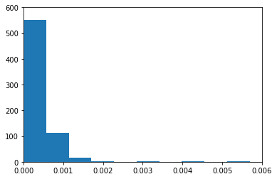

```python
plt.hist(finalData['distance_gong'])
plt.axis([0, 0.006,0,600])
```

Histgram of the new buliding to Kungfu Tea's distance distribution:

```
[0.0, 0.008, 0, 600]
```

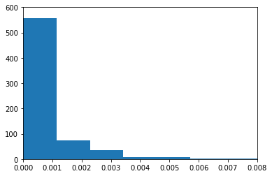

```python
plt.hist(finalData['distance_kungfu'])
plt.axis([0.000, 0.008,0,600])
```

```python
finalData = finalData[['Residential','Issuance Date','LATITUDE',
                       'LONGITUDE','TotalPop','Women','Income',
                       'Asian','Professional','distance_gong',
                       'distance_kungfu','Employed']]
```

```python
finalData.isnull().sum(axis = 0)
finalData["Income"].fillna(0, inplace=True)
```

Normalized the data to fit into the model.

```python
from sklearn import preprocessing
x = finalData[['TotalPop','Women','Income',
        'Asian','Professional','distance_gong',
        'distance_kungfu','Employed']]
min_max_scaler = preprocessing.MinMaxScaler()
x_scaled = min_max_scaler.fit_transform(x)
dataset = pd.DataFrame(x_scaled)
dataset['Residential'] = finalData['Residential']
dataset['Issuance Date'] = finalData['Issuance Date']
dataset['LATITUDE'] = finalData['LATITUDE']
dataset['LONGITUDE'] = finalData['LONGITUDE']
```

```python
dataset.columns = ['TotalPop','Women','Income',
        'Asian','Professional','distance_gong',
        'distance_kungfu','Employed','Residential','Issuance Date','LATITUDE','LONGITUDE']
dataset.sample(5)
```

|  | TotalPop | Women | Income | Asian | Professional | distance_gong | distance_kungfu | Employed | Residential | Issuance Date | LATITUDE | LONGITUDE |
| --- | --- | --- | --- | --- | --- | --- | --- | --- | --- | --- | --- | --- |
| 210 | 0.303589 | 0.230473 | 0.547476 | 0.289631 | 0.730539 | 0.041221 | 0.021244 | 0.383138 | YES | 2018-09-28 | 40.752139 | -74.001148 |
| 227 | 0.303589 | 0.230473 | 0.547476 | 0.289631 | 0.730539 | 0.044144 | 0.024152 | 0.383138 | NaN | 2018-09-24 | 40.754620 | -74.001321 |
| 509 | 0.773249 | 0.705454 | 0.084360 | 0.603099 | 0.101796 | 0.015624 | 0.005013 | 0.412918 | YES | 2018-04-16 | 40.713583 | -73.987833 |
| 652 | 0.230451 | 0.207329 | 0.546253 | 0.117998 | 0.810778 | 0.000817 | 0.000464 | 0.249024 | YES | 2018-01-18 | 40.745496 | -73.985366 |
| 592 | 0.309386 | 0.288439 | 0.462819 | 0.119190 | 0.771257 | 0.006996 | 0.001781 | 0.282604 | YES | 2018-03-05 | 40.734284 | -73.992495 |

Set the weights for different variables. The rate below are my assumptions. In reality, to acquire the rates, we need to conduct regression analysis on thoes varibales with current shops' sales, and make other adjustment based on needs.

Alternatively, the model it self could be more complicated, we could add some polynomial terms or interactive terms to our model for better selection. To better improve the model. I need more inside information about the shop itself.

```python
# Total Population:
beta_1 = 2
# Women:
beta_2 = 2
# Income Level:
beta_3 = 2
# Asian:
beta_4 = 2
# Professional:
beta_5 = 1
# Distance to current Gong Cha:
beta_6 = 3
# Distance to current kunfu Tea:
beta_7 = 3
```

$$ Value = \beta_1 * X_1 + \beta_2*X_2 + ...... + \beta_7 * X_7 $$

The places with highest target values would be the optimal places to open next Gong Cha shops

```python
dataset['score'] = beta_1*dataset['TotalPop'] + beta_2*dataset['Women'] + beta_3*dataset['Income'] + beta_4*dataset['Asian']+ beta_5*dataset['Professional'] + beta_6*dataset['distance_gong'] + beta_7*dataset['distance_kungfu']
```

```python
dataset.sort_values(by=['score'])
```

|  | TotalPop | Women | Income | Asian | Professional | distance_gong | distance_kungfu | Employed | Residential | Issuance Date | LATITUDE | LONGITUDE | score |
| --- | --- | --- | --- | --- | --- | --- | --- | --- | --- | --- | --- | --- | --- |
| 521 | 0.000000 | 0.000000 | 0.000000 | 0.000000 | 0.396407 | 0.003061 | 0.007834 | 0.000000 | NaN | 2018-04-05 | 40.752732 | -73.978138 | 0.429095 |
| 430 | 0.000000 | 0.000000 | 0.000000 | 0.000000 | 0.396407 | 0.003061 | 0.007834 | 0.000000 | NaN | 2018-05-31 | 40.752732 | -73.978138 | 0.429095 |
| 382 | 0.000000 | 0.000000 | 0.000000 | 0.000000 | 0.396407 | 0.003061 | 0.007834 | 0.000000 | NaN | 2018-06-22 | 40.752732 | -73.978138 | 0.429095 |
| 427 | 0.000000 | 0.000000 | 0.000000 | 0.000000 | 0.396407 | 0.006212 | 0.014205 | 0.000000 | NaN | 2018-06-01 | 40.756978 | -73.977408 | 0.457658 |
| 265 | 0.000000 | 0.000000 | 0.000000 | 0.000000 | 0.396407 | 0.006212 | 0.014205 | 0.000000 | NaN | 2018-08-27 | 40.756978 | -73.977408 | 0.457658 |
| 253 | 0.141465 | 0.135969 | 0.158952 | 0.067938 | 0.395210 | 0.085828 | 0.106134 | 0.100637 | YES | 2018-08-31 | 40.796231 | -73.945858 | 1.979744 |
| 600 | 0.173656 | 0.176042 | 0.215009 | 0.151371 | 0.534132 | 0.020327 | 0.003884 | 0.199014 | YES | 2018-03-01 | 40.722456 | -73.986551 | 2.038919 |
| 338 | 0.179884 | 0.172828 | 0.103523 | 0.382598 | 0.461078 | 0.019064 | 0.004442 | 0.150236 | NaN | 2018-07-16 | 40.717277 | -73.987414 | 2.209263 |
| 199 | 0.179884 | 0.172828 | 0.103523 | 0.382598 | 0.461078 | 0.019064 | 0.004442 | 0.150236 | NaN | 2018-10-02 | 40.717277 | -73.987414 | 2.209263 |
| 88 | 0.130242 | 0.109504 | 0.268140 | 0.100119 | 0.568862 | 0.016618 | 0.130868 | 0.125488 | YES | 2018-11-21 | 40.802618 | -73.957111 | 2.227329 |
| 231 | 0.130242 | 0.109504 | 0.268140 | 0.100119 | 0.568862 | 0.016618 | 0.130868 | 0.125488 | YES | 2018-09-20 | 40.802618 | -73.957111 | 2.227329 |
| 153 | 0.179884 | 0.172828 | 0.103523 | 0.382598 | 0.461078 | 0.023603 | 0.006292 | 0.150236 | YES | 2018-10-19 | 40.716868 | -73.986065 | 2.228429 |
| 89 | 0.179884 | 0.172828 | 0.103523 | 0.382598 | 0.461078 | 0.023603 | 0.006292 | 0.150236 | YES | 2018-11-21 | 40.716868 | -73.986065 | 2.228429 |
| 131 | 0.179884 | 0.172828 | 0.103523 | 0.382598 | 0.461078 | 0.023603 | 0.006292 | 0.150236 | YES | 2018-11-01 | 40.716868 | -73.986065 | 2.228429 |
| 267 | 0.307721 | 0.269045 | 0.000000 | 0.113230 | 0.834731 | 0.007022 | 0.001923 | 0.334258 | YES | 2018-08-27 | 40.717132 | -74.004574 | 2.241557 |
| 650 | 0.130242 | 0.109504 | 0.268140 | 0.100119 | 0.568862 | 0.017794 | 0.135582 | 0.125488 | YES | 2018-01-19 | 40.803290 | -73.956757 | 2.245000 |
| 439 | 0.249692 | 0.235937 | 0.139509 | 0.036949 | 0.257485 | 0.033543 | 0.187987 | 0.150647 | YES | 2018-05-23 | 40.810154 | -73.954888 | 2.246247 |
| 333 | 0.249692 | 0.235937 | 0.139509 | 0.036949 | 0.257485 | 0.033543 | 0.187987 | 0.150647 | YES | 2018-07-20 | 40.810154 | -73.954888 | 2.246247 |
| 362 | 0.307721 | 0.269045 | 0.000000 | 0.113230 | 0.834731 | 0.009885 | 0.002841 | 0.334258 | YES | 2018-07-02 | 40.718397 | -74.005574 | 2.252900 |
| 150 | 0.307721 | 0.269045 | 0.000000 | 0.113230 | 0.834731 | 0.009885 | 0.002841 | 0.334258 | YES | 2018-10-22 | 40.718397 | -74.005574 | 2.252900 |
| 364 | 0.307721 | 0.269045 | 0.000000 | 0.113230 | 0.834731 | 0.010061 | 0.002906 | 0.334258 | YES | 2018-07-02 | 40.718428 | -74.005635 | 2.253624 |
| 151 | 0.307721 | 0.269045 | 0.000000 | 0.113230 | 0.834731 | 0.010061 | 0.002906 | 0.334258 | YES | 2018-10-22 | 40.718428 | -74.005635 | 2.253624 |
| 57 | 0.179884 | 0.172828 | 0.103523 | 0.382598 | 0.461078 | 0.031715 | 0.008843 | 0.150236 | YES | 2018-12-06 | 40.718235 | -73.984557 | 2.260417 |
| 584 | 0.249692 | 0.235937 | 0.139509 | 0.036949 | 0.257485 | 0.038870 | 0.192243 | 0.150647 | YES | 2018-03-09 | 40.810581 | -73.953916 | 2.274996 |
| 423 | 0.249692 | 0.235937 | 0.139509 | 0.036949 | 0.257485 | 0.038870 | 0.192243 | 0.150647 | YES | 2018-06-05 | 40.810581 | -73.953916 | 2.274996 |
| 43 | 0.249692 | 0.235937 | 0.139509 | 0.036949 | 0.257485 | 0.038870 | 0.192243 | 0.150647 | YES | 2018-12-14 | 40.810581 | -73.953916 | 2.274996 |
| 505 | 0.249692 | 0.235937 | 0.139509 | 0.036949 | 0.257485 | 0.038870 | 0.192243 | 0.150647 | YES | 2018-04-20 | 40.810581 | -73.953916 | 2.274996 |
| 147 | 0.249692 | 0.235937 | 0.139509 | 0.036949 | 0.257485 | 0.038870 | 0.192243 | 0.150647 | YES | 2018-10-23 | 40.810581 | -73.953916 | 2.274996 |
| 216 | 0.102861 | 0.100182 | 0.476091 | 0.089392 | 0.682635 | 0.003772 | 0.019718 | 0.124974 | YES | 2018-09-27 | 40.756310 | -73.971940 | 2.290157 |
| 625 | 0.102861 | 0.100182 | 0.476091 | 0.089392 | 0.682635 | 0.008511 | 0.017167 | 0.124974 | YES | 2018-02-05 | 40.758816 | -73.972061 | 2.296722 |
| ... | ... | ... | ... | ... | ... | ... | ... | ... | ... | ... | ... | ... | ... |
| 220 | 0.625062 | 0.615879 | 0.450859 | 0.140644 | 0.759281 | 0.106309 | 0.064481 | 0.561101 | YES | 2018-09-26 | 40.776780 | -73.982987 | 4.936538 |
| 109 | 0.667551 | 0.602914 | 0.583313 | 0.034565 | 0.844311 | 0.050863 | 0.082786 | 0.606695 | YES | 2018-11-07 | 40.789248 | -73.976602 | 5.021946 |
| 65 | 0.667551 | 0.602914 | 0.583313 | 0.034565 | 0.844311 | 0.050863 | 0.082786 | 0.606695 | YES | 2018-12-04 | 40.789248 | -73.976602 | 5.021946 |
| 285 | 0.810742 | 0.810136 | 0.502678 | 0.089392 | 0.615569 | 0.151137 | 0.010540 | 0.928938 | YES | 2018-08-16 | 40.773983 | -73.954443 | 5.526496 |
| 670 | 0.810742 | 0.810136 | 0.502678 | 0.089392 | 0.615569 | 0.151137 | 0.010540 | 0.928938 | YES | 2018-01-05 | 40.773983 | -73.954443 | 5.526496 |
| 45 | 0.810742 | 0.810136 | 0.502678 | 0.089392 | 0.615569 | 0.151137 | 0.010540 | 0.928938 | YES | 2018-12-13 | 40.773983 | -73.954443 | 5.526496 |
| 286 | 0.810742 | 0.810136 | 0.502678 | 0.089392 | 0.615569 | 0.160095 | 0.012287 | 0.928938 | YES | 2018-08-16 | 40.774746 | -73.954013 | 5.558610 |
| 120 | 0.810742 | 0.810136 | 0.502678 | 0.089392 | 0.615569 | 0.160095 | 0.012287 | 0.928938 | YES | 2018-11-05 | 40.774746 | -73.954013 | 5.558610 |
| 613 | 0.810742 | 0.810136 | 0.502678 | 0.089392 | 0.615569 | 0.160095 | 0.012287 | 0.928938 | YES | 2018-02-15 | 40.774746 | -73.954013 | 5.558610 |
| 193 | 0.810742 | 0.810136 | 0.502678 | 0.089392 | 0.615569 | 0.161208 | 0.012125 | 0.928938 | YES | 2018-10-03 | 40.774370 | -73.953439 | 5.561466 |
| 348 | 0.810742 | 0.810136 | 0.502678 | 0.089392 | 0.615569 | 0.161208 | 0.012125 | 0.928938 | YES | 2018-07-11 | 40.774370 | -73.953439 | 5.561466 |
| 473 | 0.905155 | 0.894568 | 0.343178 | 0.110846 | 0.669461 | 0.137210 | 0.036669 | 0.878106 | YES | 2018-05-08 | 40.781779 | -73.948884 | 5.698592 |
| 108 | 0.905155 | 0.894568 | 0.343178 | 0.110846 | 0.669461 | 0.137210 | 0.036669 | 0.878106 | YES | 2018-11-07 | 40.781779 | -73.948884 | 5.698592 |
| 622 | 0.905155 | 0.894568 | 0.343178 | 0.110846 | 0.669461 | 0.137210 | 0.036669 | 0.878106 | YES | 2018-02-06 | 40.781779 | -73.948884 | 5.698592 |
| 472 | 0.905155 | 0.894568 | 0.343178 | 0.110846 | 0.669461 | 0.137084 | 0.036849 | 0.878106 | YES | 2018-05-08 | 40.781820 | -73.948855 | 5.698755 |
| 107 | 0.905155 | 0.894568 | 0.343178 | 0.110846 | 0.669461 | 0.137084 | 0.036849 | 0.878106 | YES | 2018-11-07 | 40.781820 | -73.948855 | 5.698755 |
| 673 | 0.905155 | 0.894568 | 0.343178 | 0.110846 | 0.669461 | 0.134967 | 0.040358 | 0.878106 | NaN | 2018-01-04 | 40.782597 | -73.948292 | 5.702932 |
| 6 | 0.905155 | 0.894568 | 0.343178 | 0.110846 | 0.669461 | 0.134967 | 0.040358 | 0.878106 | NaN | 2018-12-29 | 40.782597 | -73.948292 | 5.702932 |
| 138 | 0.532560 | 0.406193 | 0.138392 | 0.017878 | 0.079042 | 0.586046 | 0.702366 | 0.456973 | YES | 2018-10-29 | 40.849488 | -73.932321 | 6.134324 |
| 544 | 0.978355 | 1.000000 | 0.461179 | 0.059595 | 0.692216 | 0.188155 | 0.016357 | 1.000000 | YES | 2018-03-27 | 40.771277 | -73.947452 | 6.304010 |
| 211 | 0.978355 | 1.000000 | 0.461179 | 0.059595 | 0.692216 | 0.196716 | 0.018129 | 1.000000 | YES | 2018-09-28 | 40.771902 | -73.946997 | 6.335009 |
| 275 | 0.978355 | 1.000000 | 0.461179 | 0.059595 | 0.692216 | 0.196716 | 0.018129 | 1.000000 | YES | 2018-08-21 | 40.771902 | -73.946997 | 6.335009 |
| 580 | 0.978355 | 1.000000 | 0.461179 | 0.059595 | 0.692216 | 0.208871 | 0.020704 | 1.000000 | NaN | 2018-03-12 | 40.773184 | -73.946689 | 6.379198 |
| 124 | 0.495868 | 0.417122 | 0.262025 | 0.028605 | 0.408383 | 0.511264 | 0.677847 | 0.461388 | YES | 2018-11-02 | 40.849857 | -73.939788 | 6.382957 |
| 378 | 1.000000 | 0.847745 | 0.150322 | 0.017878 | 0.161677 | 0.281470 | 0.459676 | 0.783118 | YES | 2018-06-26 | 40.834362 | -73.941732 | 6.417004 |
| 379 | 1.000000 | 0.847745 | 0.150322 | 0.017878 | 0.161677 | 0.298580 | 0.481103 | 0.783118 | YES | 2018-06-25 | 40.836168 | -73.942103 | 6.532613 |
| 394 | 1.000000 | 0.847745 | 0.150322 | 0.017878 | 0.161677 | 0.299649 | 0.480038 | 0.783118 | YES | 2018-06-20 | 40.836003 | -73.941763 | 6.532627 |
| 421 | 0.281574 | 0.262081 | 0.100491 | 0.000000 | 0.130539 | 0.931475 | 0.935269 | 0.156398 | NaN | 2018-06-06 | 40.860433 | -73.921855 | 7.019061 |
| 281 | 0.426739 | 0.407157 | 0.316923 | 0.052443 | 0.772455 | 0.734054 | 0.844288 | 0.399158 | NaN | 2018-08-17 | 40.859030 | -73.934296 | 7.914007 |
| 462 | 0.759867 | 0.699882 | 0.122074 | 0.015495 | 0.073054 | 1.000000 | 1.000000 | 0.533580 | NaN | 2018-05-14 | 40.864644 | -73.923094 | 9.267690 |

686 rows × 13 columns

```python
NY_COORDINATES = [40.78, -73.97]
# for speed purposes
MAX_RECORDS = 10000
# create empty map zoomed in on San Francisco
map = folium.Map(location=NY_COORDINATES, zoom_start=12,tiles = "Stamen Terrain",)
for each in dataset.head(10).iterrows():
    #print(each)
    folium.Marker(
        [each[1]['LATITUDE'],each[1]['LONGITUDE']],
        icon=folium.Icon(color='green')).add_to(map)

for each in gong_cha.iterrows():
    #print(each)
    folium.Marker(
        [each[1]['lat'],each[1]['long']],
        icon=folium.Icon(color='blue')).add_to(map)
```

```python
display(map)
```

[interactive chart not shown]